# EDA_Project

# Candidate Contributions by Alejandro Garcia

The following dataset is about the Financial contributions that took place for the state of Texas during the 2016 election year. It contains data on minor information on the contributors and the amounts they contributed to the candidates as well as candidate names, commitee ids, and candidate ids.

# Univariate Plots Section

```
## 'data.frame':    548396 obs. of  18 variables:
##  $ cmte_id          : chr  "C00575795" "C00580100" "C00580100" "C00577130" ...
##  $ cand_id          : Factor w/ 25 levels "P00003392","P20002671",..: 1 23 23 12 1 1 23 23 1 23 ...
##  $ cand_nm          : Factor w/ 25 levels "Bush, Jeb","Carson, Benjamin S.",..: 4 23 23 20 4 4 23 23 4 23 ...
##  $ contbr_nm        : Factor w/ 129927 levels "'CALL, JANE",..: 78846 104629 104633 67432 47336 126503 99534 93791 58977 93812 ...
##  $ contbr_city      : Factor w/ 2252 levels "","-2111",". FREEPORT.       PAY FOR EMPL",..: 427 699 2200 1474 1802 116 1858 965 1918 1248 ...
##  $ contbr_st        : Factor w/ 1 level "TX": 1 1 1 1 1 1 1 1 1 1 ...
##  $ contbr_zip       : Factor w/ 66332 levels "","00000","000078043",..: 50059 18338 32877 19908 48359 57008 45708 32935 17812 17201 ...
##  $ contbr_employer  : Factor w/ 40164 levels "","'CALL PHONOGRAPH LLC",..: 24038 3596 28912 24933 6082 9778 17644 17644 8244 30753 ...
##  $ contbr_occupation: Factor w/ 17467 levels "","-"," CERTIFIED REGISTERED NURSE ANESTHETIS",..: 13568 13238 13568 10154 14388 14007 7704 7704 11436 7239 ...
##  $ contb_receipt_amt: num  37.1 127.1 80 15 50 ...
##  $ contb_receipt_dt : Factor w/ 746 levels "01-APR-15","01-APR-16",..: 359 681 6 132 191 72 701 725 484 91 ...
##  $ receipt_desc     : Factor w/ 61 levels "","* EARMARKED CONTRIBUTION: SEE BELOW REATTRIBUTION/REFUND PENDING",..: 1 1 1 1 1 1 1 1 1 1 ...
##  $ memo_cd          : Factor w/ 2 levels "","X": 2 2 2 1 2 2 2 2 2 2 ...
##  $ memo_text        : Factor w/ 291 levels "","$0.10 REFUNDED ON 10/24/2016",..: 40 1 1 31 40 40 1 1 40 1 ...
##  $ form_tp          : Factor w/ 3 levels "SA17A","SA18",..: 2 2 2 1 2 2 2 2 2 2 ...
##  $ file_num         : int  1091718 1146165 1146165 1077404 1091718 1091718 1146165 1146165 1091718 1146165 ...
##  $ tran_id          : Factor w/ 543825 levels "A0009C127D0D344E3885",..: 139500 461349 403810 493948 139256 139041 429428 400817 139706 461688 ...
##  $ election_tp      : Factor w/ 5 levels "","G2016","O2016",..: 5 2 2 5 5 5 2 2 5 2 ...
```

Structure of the dataset

```
## [1] 548396     18
```

Dataset dimensions

```
##     cmte_id   cand_id                 cand_nm          contbr_nm
## 1 C00575795 P00003392 Clinton, Hillary Rodham  MILLARD, SUSAN C.
## 2 C00580100 P80001571        Trump, Donald J. SELLERS, CHRISTINE
## 3 C00580100 P80001571        Trump, Donald J.     SELLERS, DAVID
## 4 C00577130 P60007168        Sanders, Bernard    LEONE, MICHELLE
## 5 C00575795 P00003392 Clinton, Hillary Rodham       HAMMAD, HANI
## 6 C00575795 P00003392 Clinton, Hillary Rodham     WILSON, TAYLOR
##            contbr_city contbr_st contbr_zip          contbr_employer
## 1       CORPUS CHRISTI        TX  784112213                      N/A
## 2           FORT WORTH        TX      76108 BAYLOR HEALTHCARE SYSTEM
## 3               WILLIS        TX      77318                  RETIRED
## 4 NORTH RICHLAND HILLS        TX  761826749             NOT EMPLOYED
## 5          SAN ANTONIO        TX  782481936            CARZ OF TEXAS
## 6               AUSTIN        TX  787287173                DELL INC.
##   contbr_occupation contb_receipt_amt contb_receipt_dt receipt_desc
```

[output cut: 20 more lines]

```
##          cmte_id   cand_id                 cand_nm
## 548391 C00575795 P00003392 Clinton, Hillary Rodham
## 548392 C00575795 P00003392 Clinton, Hillary Rodham
## 548393 C00575795 P00003392 Clinton, Hillary Rodham
## 548394 C00575795 P00003392 Clinton, Hillary Rodham
## 548395 C00575795 P00003392 Clinton, Hillary Rodham
## 548396 C00575795 P00003392 Clinton, Hillary Rodham
##                            contbr_nm contbr_city contbr_st contbr_zip
## 548391        RUCKER-SCHMIDT, RACHEL      DALLAS        TX  752257428
## 548392                   HANSON, TIM      ODESSA        TX  797627138
## 548393 MACNAUGHTON BRUNE, ANN LOUISE     HOUSTON        TX  770985429
## 548394                MALONEY, BRYAN      DALLAS        TX  752064963
## 548395                KOTLYAR, BRIAN      AUSTIN        TX  787021723
## 548396             JOHNSTON, MELINDA WEATHERFORD        TX  760876320
##         contbr_employer       contbr_occupation contb_receipt_amt
```

[output cut: 20 more lines]

```
## cand_nm: Bush, Jeb
##    Min. 1st Qu.  Median    Mean 3rd Qu.    Max.
##   -5400     100     500    1025    2700   15000
## --------------------------------------------------------
## cand_nm: Carson, Benjamin S.
##    Min. 1st Qu.  Median    Mean 3rd Qu.    Max.
## -7100.0    25.0    50.0   128.5   100.0 10000.0
## --------------------------------------------------------
## cand_nm: Christie, Christopher J.
##    Min. 1st Qu.  Median    Mean 3rd Qu.    Max.
##   -2700     100    1000    1384    2700    5400
## --------------------------------------------------------
## cand_nm: Clinton, Hillary Rodham
##    Min. 1st Qu.  Median    Mean 3rd Qu.    Max.
## -5400.0    10.0    25.0   110.9    75.0  5400.0
## --------------------------------------------------------
## cand_nm: Cruz, Rafael Edward 'Ted'
##     Min.  1st Qu.   Median     Mean  3rd Qu.     Max.
## -16600.0     25.0     50.0    142.3    100.0  10800.0
## --------------------------------------------------------
## cand_nm: Fiorina, Carly
##    Min. 1st Qu.  Median    Mean 3rd Qu.    Max.
## -2700.0    50.0   100.0   245.4   250.0  5000.0
## --------------------------------------------------------
## cand_nm: Gilmore, James S III
##    Min. 1st Qu.  Median    Mean 3rd Qu.    Max.
##    1000    2700    2700    2360    2700    2700
## --------------------------------------------------------
## cand_nm: Graham, Lindsey O.
##    Min. 1st Qu.  Median    Mean 3rd Qu.    Max.
##   -2700     100     500     853    1500    5400
## --------------------------------------------------------
## cand_nm: Huckabee, Mike
##    Min. 1st Qu.  Median    Mean 3rd Qu.    Max.
## -2700.0    27.2   100.0   424.1   500.0  5400.0
## --------------------------------------------------------
## cand_nm: Jindal, Bobby
##    Min. 1st Qu.  Median    Mean 3rd Qu.    Max.
## -2700.0   100.0   250.0   778.6  1375.0  2700.0
## --------------------------------------------------------
```

[output cut: 44 more lines]

```
## cand_nm: Stein, Jill
##    Min. 1st Qu.  Median    Mean 3rd Qu.    Max.
##     4.2    40.0   100.0   243.1   250.0  2700.0
## --------------------------------------------------------
## cand_nm: Trump, Donald J.
##    Min. 1st Qu.  Median    Mean 3rd Qu.    Max.
## -5200.0    28.0    80.0   201.4   200.0  5400.0
## --------------------------------------------------------
## cand_nm: Walker, Scott
##    Min. 1st Qu.  Median    Mean 3rd Qu.    Max.
## -2700.0   168.8   500.0   791.2  1000.0  5400.0
## --------------------------------------------------------
## cand_nm: Webb, James Henry Jr.
##    Min. 1st Qu.  Median    Mean 3rd Qu.    Max.
##    20.0   100.0   300.0   529.1   500.0  2700.0
```

Head and tail data and contribution candidate summary

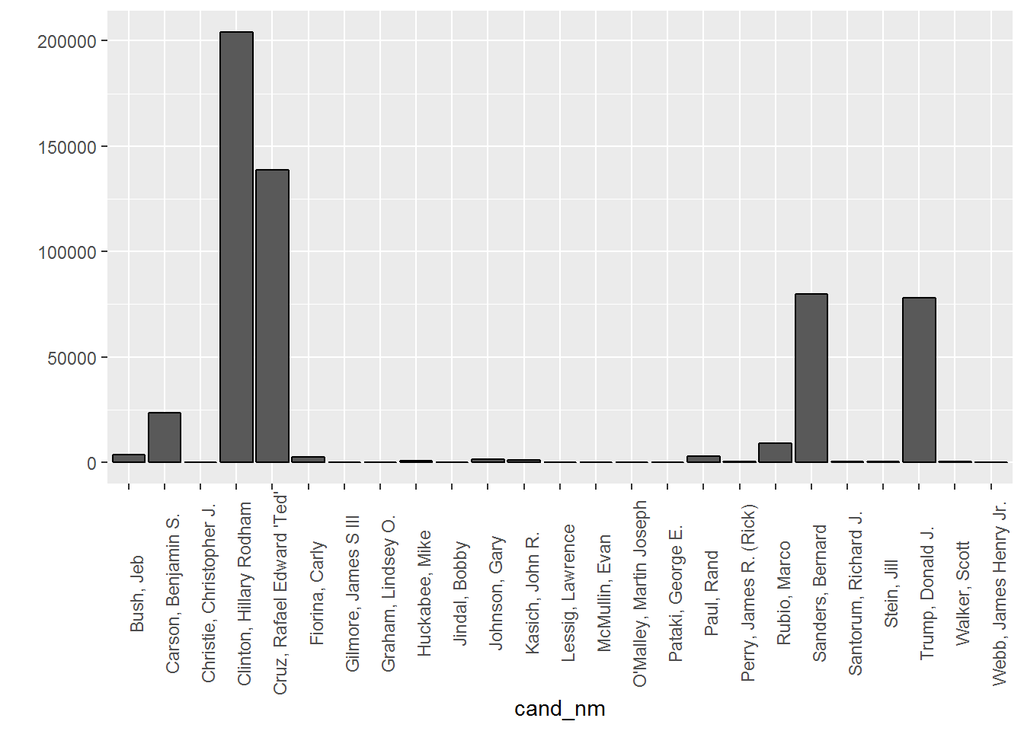

Contributions made to each candidate

```
##
##        <0     0-200   201-500  501-1000 1001-2000    2001 >
##     12108    467077     44835     10766      2516     11094
```

Contribution brackets

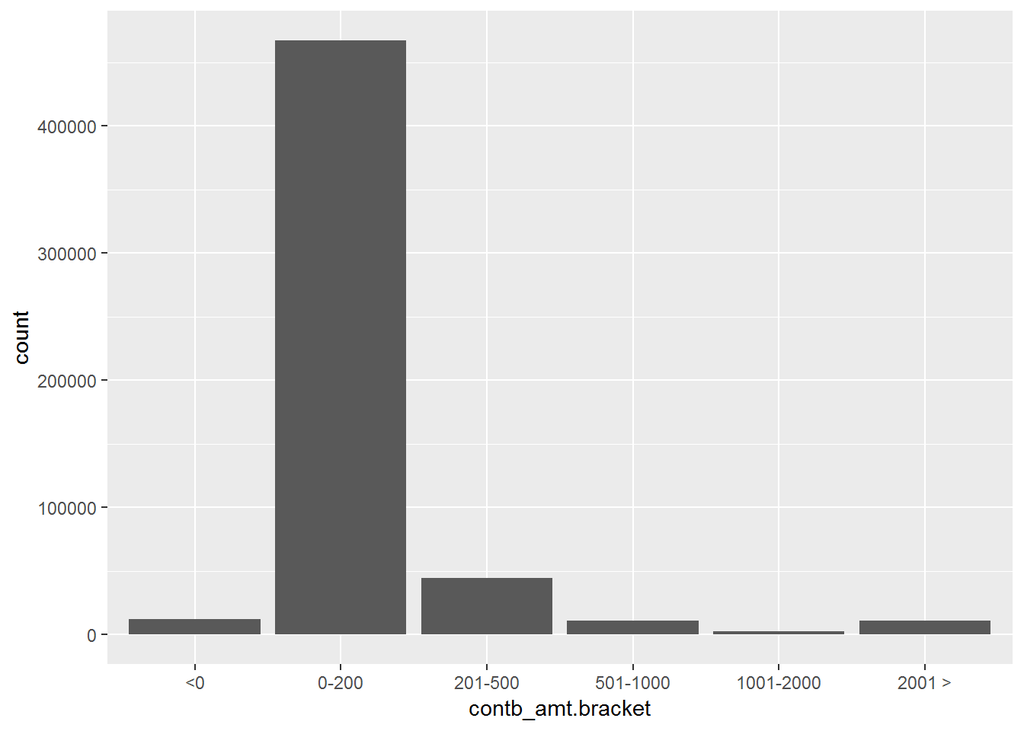

A plot of the contribution amount brackets

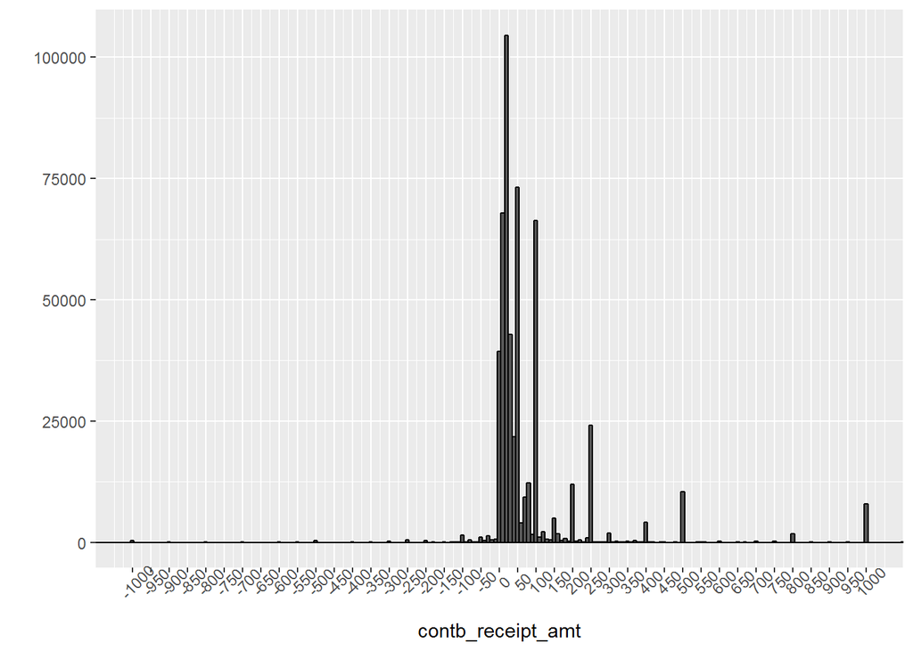

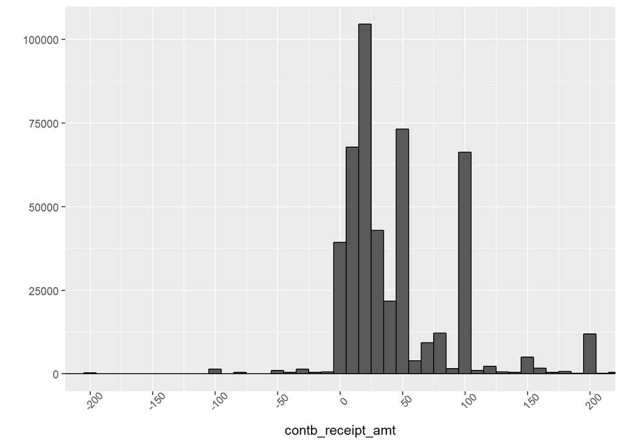

```
##     Min.  1st Qu.   Median     Mean  3rd Qu.     Max.
## -16600.0     20.0     38.0    138.2    100.0  15000.0
```

Contribution Amount Summary and Charts

```
##
##    01    02    03    04    05    06    07    08    09    10    11    12
## 16902 21237 16230 15103 23119 18301 17076 18198 17790 15870 18031 19891
##    13    14    15    16    17    18    19    20    21    22    23    24
## 12657 16241 17114 17540 13566 14612 18034 15528 16233 14634 15146 12201
##    25    26    27    28    29    30    31
## 14283 17773 16044 20703 28869 27593 21877
```

```
##
##   JAN   FEB   MAR   APR   MAY   JUN   JUL   AUG   SEP   OCT   NOV   DEC
## 25575 49043 56585 50183 34262 38354 57732 49827 52847 68920 41101 23967
```

```
##
##     13     14     15     16
##      4    140 101223 447029
```

Creation of contribution day, month, and year columns.

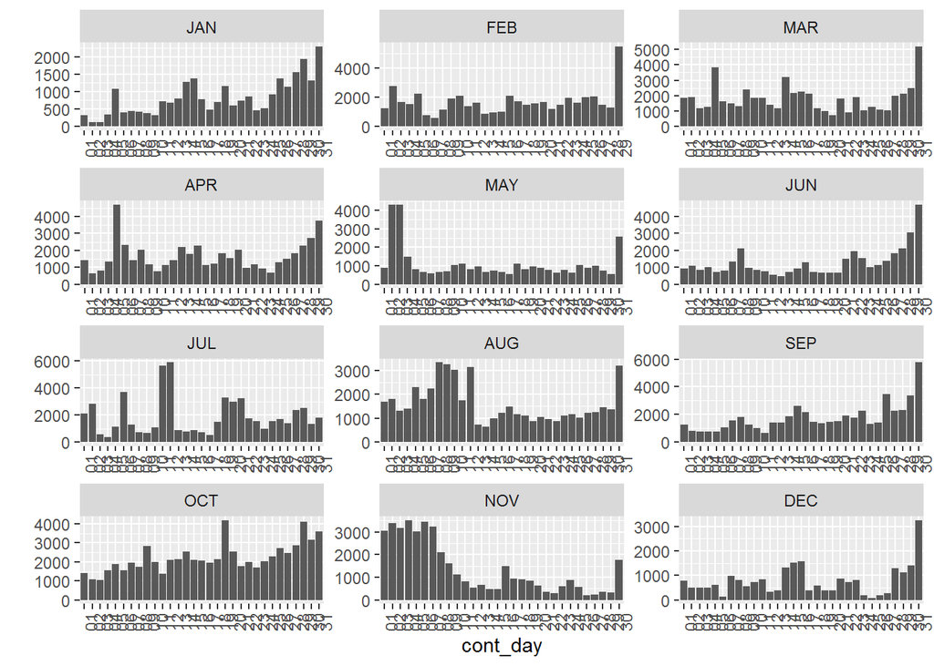

Contributions made per day split by month and containing all years.

# Univariate Analysis

### What is the structure of your dataset?

The current structure of my dataset consist of 548,396 observations and 21 variables.

### What is/are the main feature(s) of interest in your dataset?

I am interested in finding the amount of contributions made to those candidates running for the 2016 presidential elections in the state of TX.

### What other features in the dataset do you think will help support your investigation into your feature(s) of interest?

cand_nam, contbr_nm, contb_receipt_amt, cont_day,month, and contb_amt.bracket

### Did you create any new variables from existing variables in the dataset?

I had to create the cont_day, cont_month_, and cont_year which replaced the contbr_receipt_dt. The contb_amt.bracket was also created to help reduce the amount of bins needed to capture all of the dollar amounts contributed.

### Of the features you investigated, were there any unusual distributions? Did you perform any operations on the data to tidy, adjust, or change the form of the data? If so, why did you do this?

Of the features I investigated, I did not notice any unusual distributions. But I did notice that contbr_zip and contbr_city were not usable since some zip codesand cities were made up or other countries.

# Bivariate Plots Section

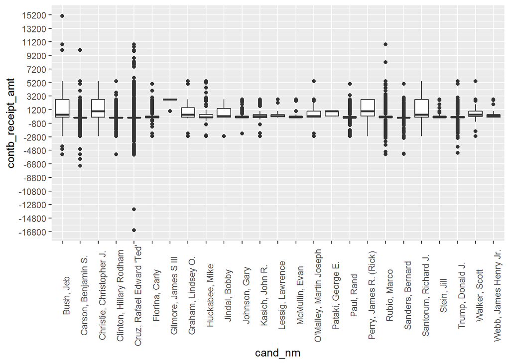

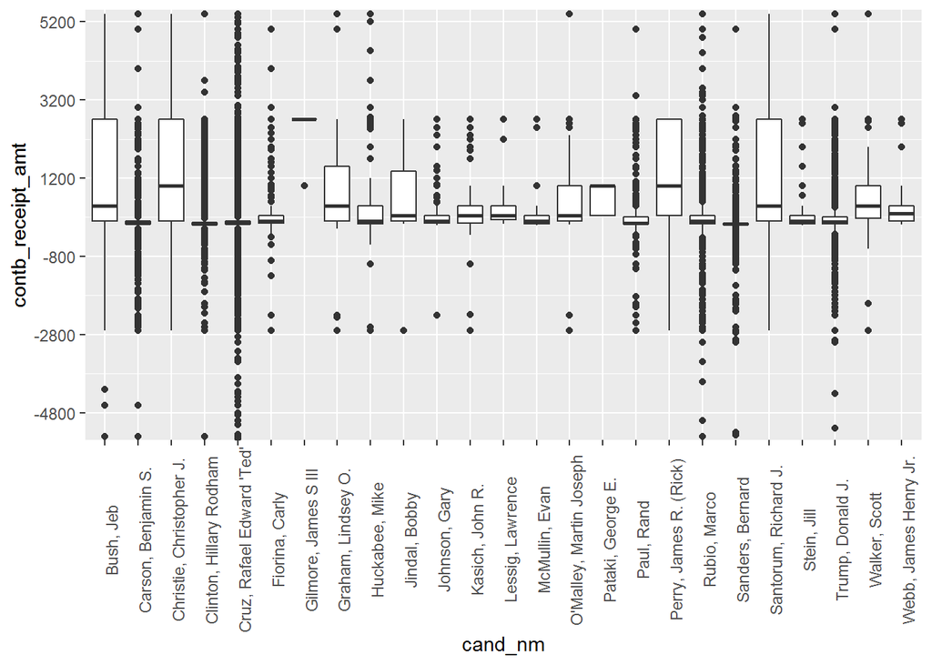

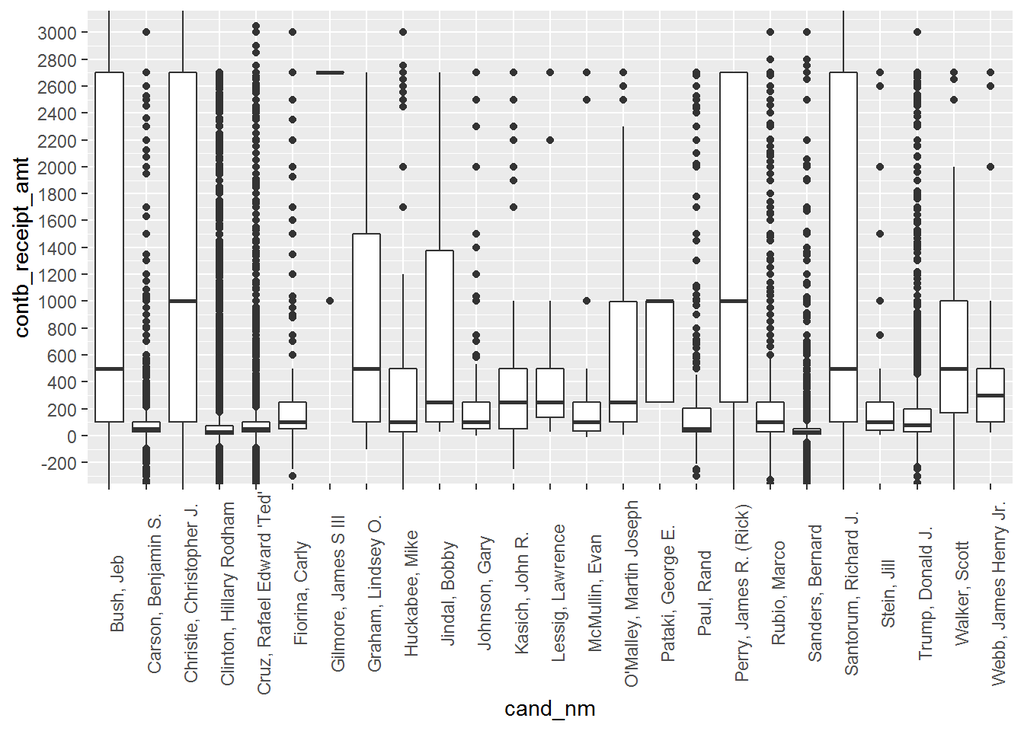

Zooming in on candidate contribution amounts

```
## [1] 138.2023
```

```
## [1] 38
```

```
##     Min.  1st Qu.   Median     Mean  3rd Qu.     Max.
## -16600.0     20.0     38.0    138.2    100.0  15000.0
```

Contribution amount mean, median, and summary

```
## fc$cand_nm
##   Clinton, Hillary Rodham Cruz, Rafael Edward 'Ted'
##               22623320.68               19751235.61
##          Trump, Donald J.                 Bush, Jeb
##               15692433.30                3667657.09
##          Sanders, Bernard       Carson, Benjamin S.
##                3414515.30                3045078.33
##              Rubio, Marco    Perry, James R. (Rick)
##                2901204.76                 749339.52
##                Paul, Rand            Fiorina, Carly
##                 672115.48                 623492.56
##           Kasich, John R.             Walker, Scott
##                 511613.00                 394033.00
##             Johnson, Gary            Huckabee, Mike
##                 323761.81                 310856.15
##      Santorum, Richard J.  Christie, Christopher J.
##                 288638.20                 274005.00
##   O'Malley, Martin Joseph        Graham, Lindsey O.
##                 154262.00                 150986.00
##               Stein, Jill             Jindal, Bobby
##                  88505.17                  45160.00
##            McMullin, Evan     Webb, James Henry Jr.
##                  38077.00                  31215.16
##          Lessig, Lawrence      Gilmore, James S III
##                  20277.94                  11800.00
##         Pataki, George E.
##                   6000.00
```

```
## fc$cand_nm
##   Clinton, Hillary Rodham Cruz, Rafael Edward 'Ted'
##                    203942                    138805
##          Sanders, Bernard          Trump, Donald J.
##                     79955                     77920
##       Carson, Benjamin S.              Rubio, Marco
##                     23694                      8984
##                 Bush, Jeb                Paul, Rand
##                      3578                      3047
##            Fiorina, Carly             Johnson, Gary
##                      2541                      1336
##           Kasich, John R.            Huckabee, Mike
##                      1187                       733
##    Perry, James R. (Rick)             Walker, Scott
##                       574                       498
##               Stein, Jill      Santorum, Richard J.
##                       364                       275
##   O'Malley, Martin Joseph  Christie, Christopher J.
##                       228                       198
##            McMullin, Evan        Graham, Lindsey O.
##                       197                       177
##     Webb, James Henry Jr.             Jindal, Bobby
##                        59                        58
##          Lessig, Lawrence         Pataki, George E.
##                        32                         9
##      Gilmore, James S III
##                         5
```

Contribution amounts by candidate and contributors count by candidate.

```
## # A tibble: 25 x 3
##    cand_nm                   total_contb_amt total_contb_ct
##    <fct>                               <dbl>          <int>
##  1 Bush, Jeb                        3667657.           3578
##  2 Carson, Benjamin S.              3045078.          23694
##  3 Christie, Christopher J.          274005             198
##  4 Clinton, Hillary Rodham         22623321.         203942
##  5 Cruz, Rafael Edward 'Ted'       19751236.         138805
##  6 Fiorina, Carly                    623493.           2541
##  7 Gilmore, James S III               11800               5
##  8 Graham, Lindsey O.                150986             177
##  9 Huckabee, Mike                    310856.            733
## 10 Jindal, Bobby                      45160              58
## # ... with 15 more rows
```

fc.sum Data all rows

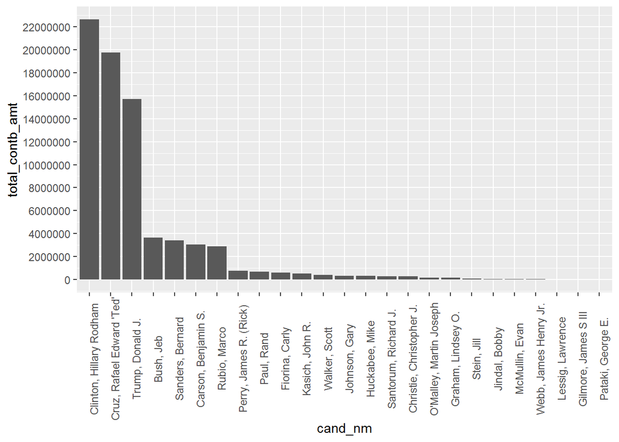

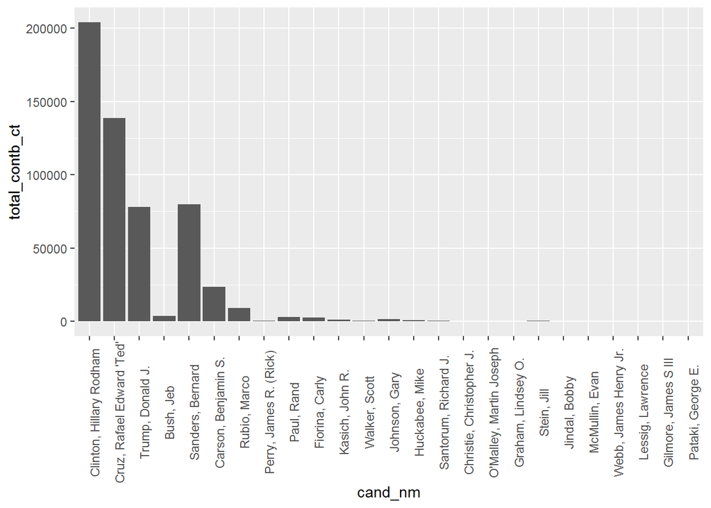

The barplot shows total contribution amounts in the first plot and total contributors in the second plot

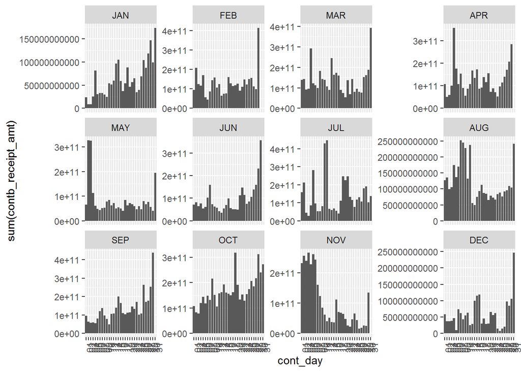

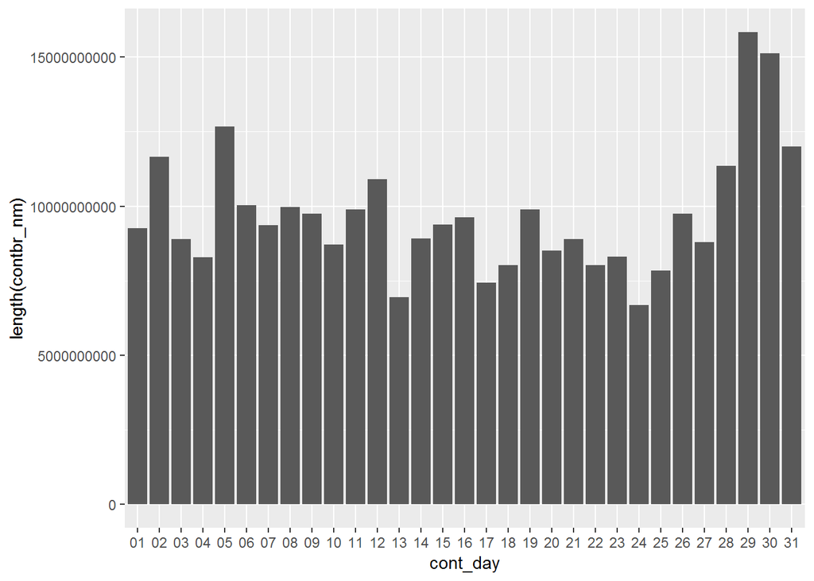

# Bivariate Analysis

### Talk about some of the relationships you observed in this part of the investigation. How did the feature(s) of interest vary with other features in the dataset?

In this section I wanted to look at the amount of money a candadite received everyday for the two or three years where contributors donated money. I also focused on the combined number of contributions in a month.

### Did you observe any interesting relationships between the other features (not the main feature(s) of interest)?

In this section I decided to create a new set of data that contained the contribution amounts each candidated received and the amount of contributors. Althought Hillary Clintion did not win the election she had the highest amount of contributors with 203K and the highest contribution amount of $22.6 million.

### What was the strongest relationship you found?

Unfortuntaly I was unable to perform a cor test to find any strong correlations between the data my dataset contained. The majority of my data is factor based and numerical values are needed to perform a cor test.

# Multivariate Plots Section

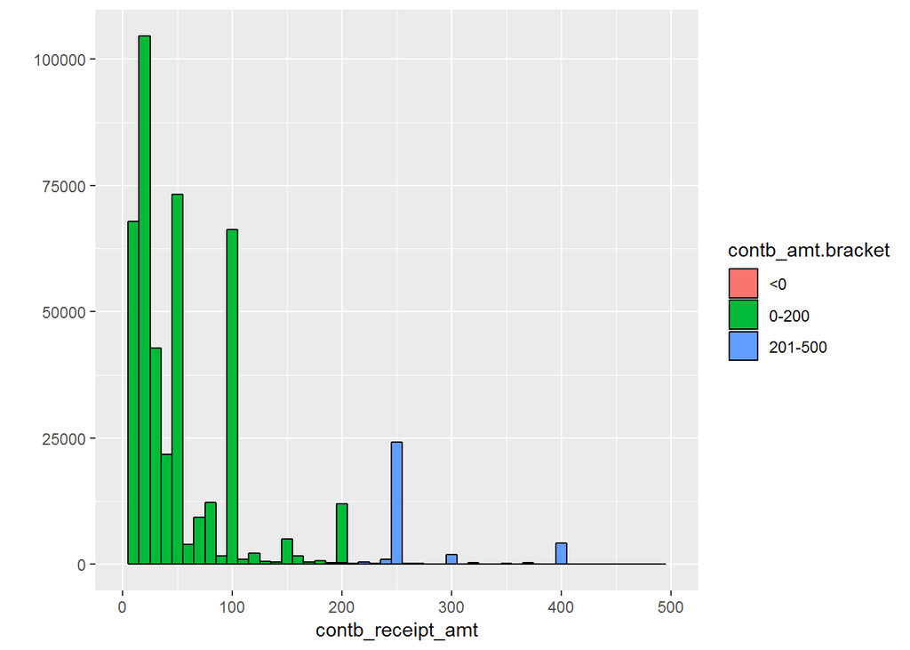

Plot showing 95% of the contributions made to all candidates

```
## [1] 26654520
```

Sum of contributions less than or equal to $500

```
## [1] 41009724
```

Sum of contributions less than or equal to $2000

```
## [1] 76994.23
```

Sum of contributions made in December of 2016

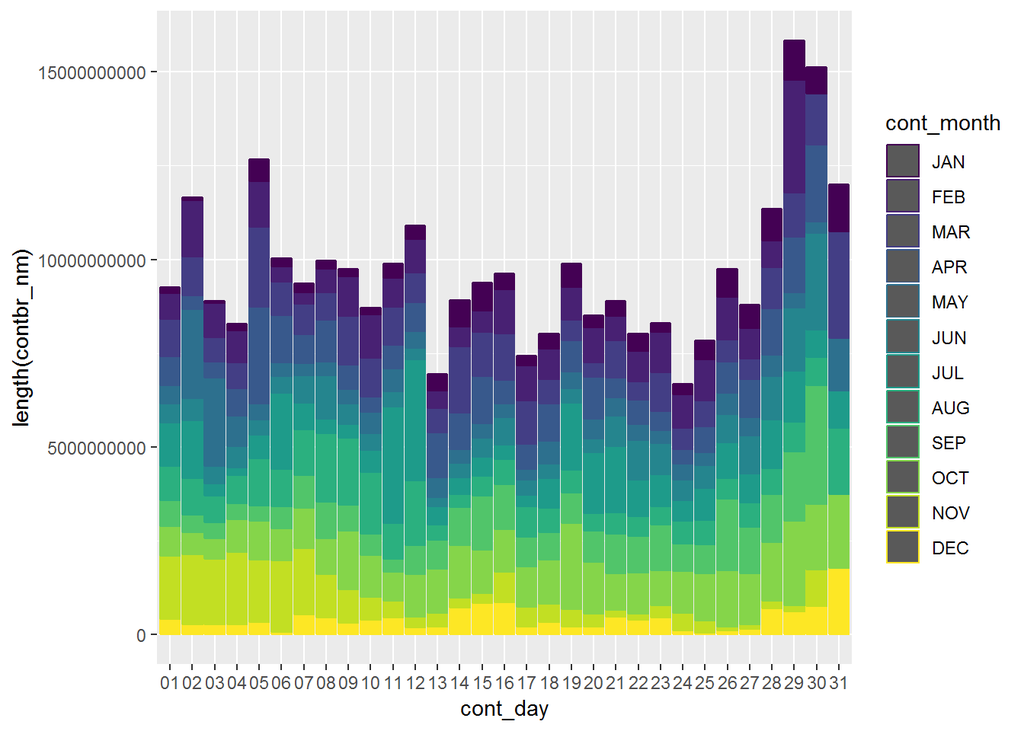

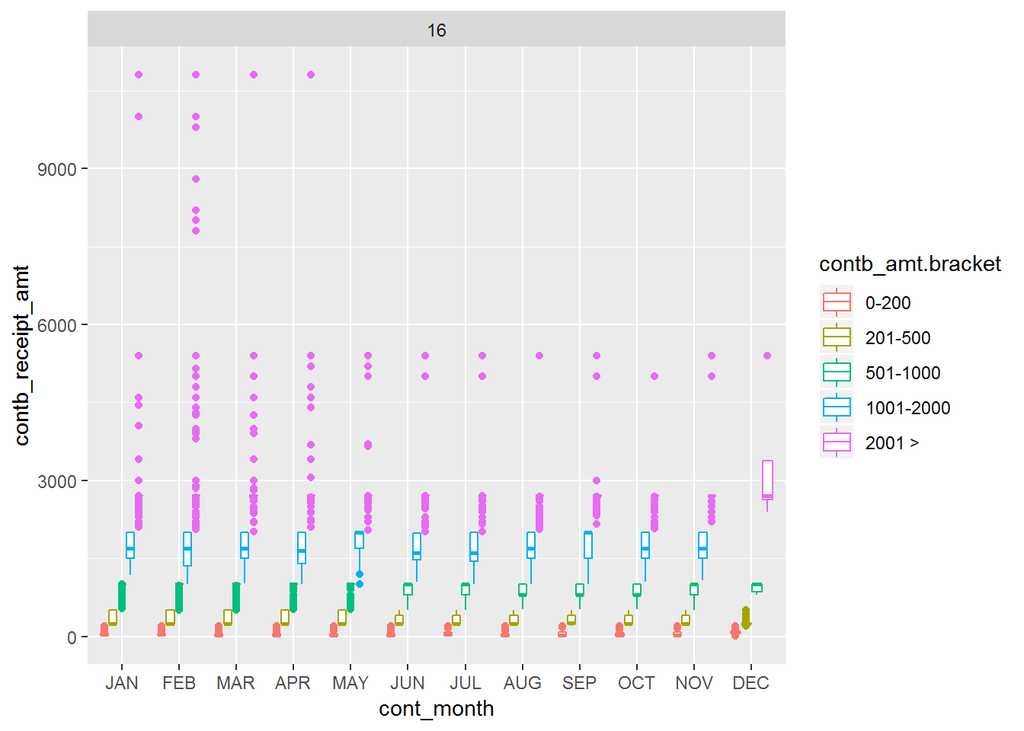

Contribution amounts divided by months and contribution amount brackets

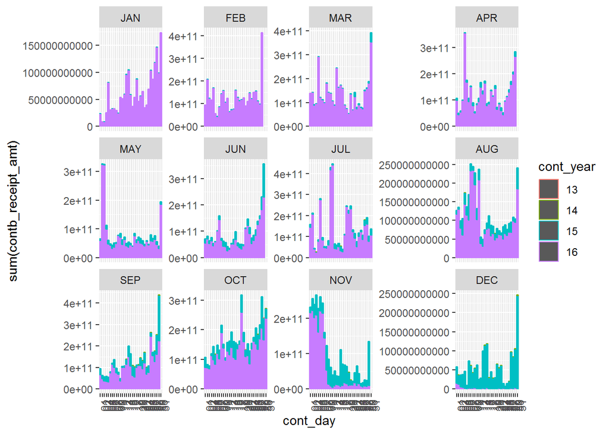

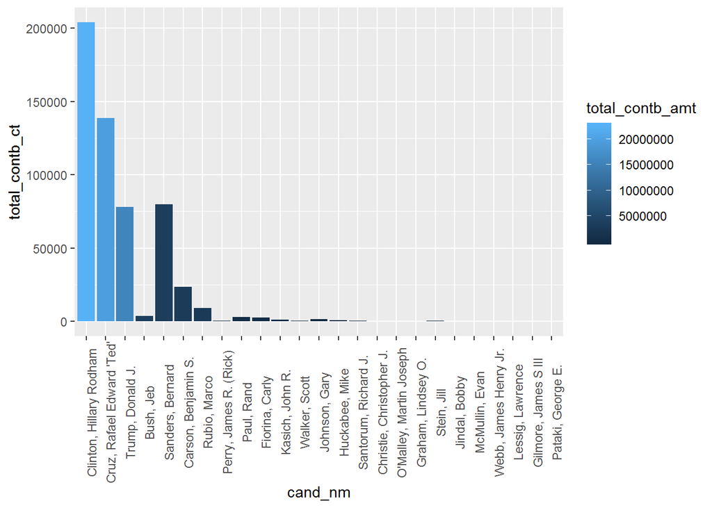

Contributions each candidate received during the 2016 election colored by amount

# Multivariate Analysis

### Were there any interesting or surprising interactions between features?

95% of the contribution amounts were under $500 dollars which equate to $26,654,520. As mentioned above during the month of December of 2016 $76994.23 was contributed to the campains.

# Final Plots and Summary

```
## DT
##    25    50   100    10     5   250
## 80376 69794 65084 37692 28008 24001
```

### Plot One

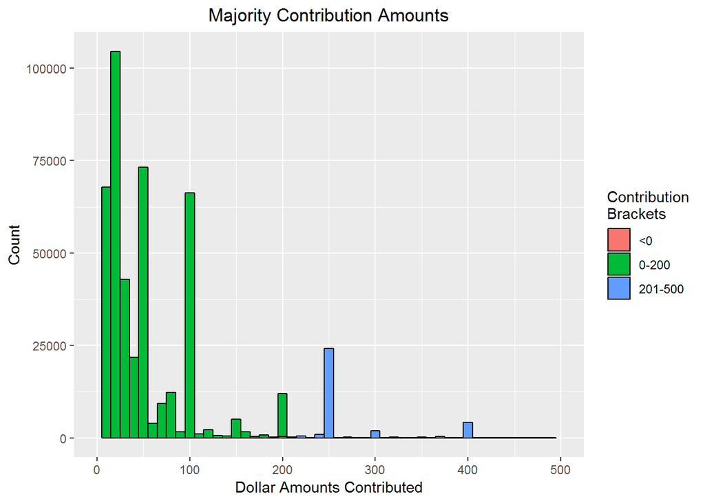

### Description One

Here we take a look at the contribution amounts by brackets. 95% of the contribution amounts were under $500. There were over 80,000 contributions of $25 made with the next highest contribution amount being $50 with a count of 69,794.

### Plot Two

[figure not shown]

### Plot Three

[figure not shown]

# Reflection

So this was a pretting interesting data set to work with. It contained the presidential election contribution information on the candidates and those who contributed to the campaigns. The dataset was based on the contributions from the great state of Texas. Although the state of Texas itself is a mostly Republican state there was quite a surprise when I found that a Democrat won out on the number of contributions made and the total amount of contributions made. I did have a bit of trouble with the dataset itself though, it was mostly comprived of strings and factors unlike the daimonds dataset which makes it easier to work with since it has a ton of numeric based data. The main variables used were cand_nm, contb_nm, contb_receipt_amt, cont_day, cont_month,cont_year, and contb_amt.bracket. If I were to work with this dataset again in the future I might try and divide candidates into their respective political groups.